# Modelagem Preditiva Avançada

## Regressão Linear - Teoria

#### Datasets & PPT: https://github.com/rbarsotti/MBA/archive/master.zip

| Feature | Descrição | Tipo |
| --- | --- | --- |
| AGE | Idade em Dias | Real |
| TEMPERATURE | Temperatura da Agua | Real |
| SIZE | Tamanho do Peixe | Real |

Passo 1)

Primeiramente vamos importar os seguinter pacotes:

caret: Biblioteca para funcionalidade de ML mlbench: Biblioteca para Validação de Modelos ggplot2: Biblioteca para visualização de dados

```r
library(caret)
library(mlbench)
library(ggplot2)
```

Passo 2)

Agora vamos carregar o dataset, com cabeçalho (header=TRUE) e o separador de colunas sendo ','.

```r
df <- read.csv(file="/home/barsotti/Desktop/FIsh.csv", header=TRUE, sep=",")
```

Passo 3)

Agora vamos fazer uma rápida análise dos dados buscando identificar algumas relações visualmente e também verificar a qualidade dos dados.

### Análise dos Dados

```r
head(df)
```

| AGE | TEMPERATURE | SIZE |
| --- | --- | --- |
| 14 | 25 | 620 |
| 28 | 25 | 1315 |
| 41 | 25 | 2120 |
| 55 | 25 | 2600 |
| 69 | 25 | 3110 |
| 83 | 25 | 3535 |

```r
df$AGE <- as.numeric(df$AGE)
df$TEMPERATURE <- as.numeric(df$TEMPERATURE)
df$SIZE <- as.numeric(df$SIZE)
```

```r
summary(df)
```

```
      AGE          TEMPERATURE        SIZE
 Min.   : 14.00   Min.   :25.0   Min.   : 590
 1st Qu.: 41.00   1st Qu.:26.5   1st Qu.:2135
 Median : 83.00   Median :28.0   Median :3197
 Mean   : 83.18   Mean   :28.0   Mean   :3107
 3rd Qu.:125.00   3rd Qu.:29.5   3rd Qu.:4500
 Max.   :153.00   Max.   :31.0   Max.   :4600
```

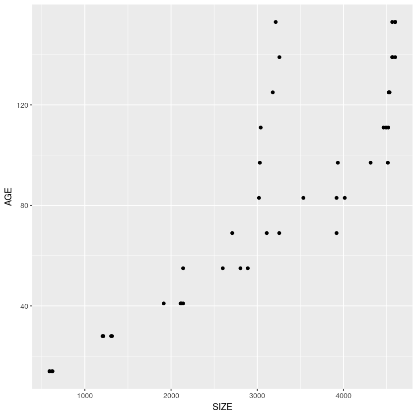

```r
ggplot(data = df, aes(x = SIZE, y = AGE)) +
  geom_point()
```

### Particionando Dados em Treino e Teste

Passo 4)

Agora vamos particionar o dataset em treino/teste. Para isso definimos "p=0.7", isto é 70% da base será escolhida aleatóriamente para treino e 30% para teste do modelo.

Observe também que o "set.seed(x)" garante que ao replicarmos essa partição em outro computador por exemplo, os mesmos dados irão respectivamente prar treino e teste

```r
set.seed(280)
trainIndex <- createDataPartition(df$SIZE, p = .7, list = FALSE)
```

```r
dfTrain <- df[ trainIndex,]
dfTest  <- df[-trainIndex,]
```

### Treinando Modelo Univariado

Passo 5)

```r
set.seed(130)
model_uni <- train(SIZE~AGE, data = dfTrain ,method = "lm")
```

### Validação Modelo

Passo 6)

Chamando o modelo obtemos informações como:

Número de amostras no treino

R<sup>2</sup>

etc

```r
model_uni
```

```
Linear Regression

32 samples
 1 predictor

No pre-processing
Resampling: Bootstrapped (25 reps)
Summary of sample sizes: 32, 32, 32, 32, 32, 32, ...
Resampling results:

  RMSE      Rsquared   MAE
  597.2838  0.7915246  494.5645

Tuning parameter 'intercept' was held constant at a value of TRUE
```

Passo 7)

Abaixo agora vamos obter os coeficientes do modelo, isto é:

$y = \alpha_1(X_1) + \alpha_2(X_2) + \alpha_3(X_3) ....$

$SIZE = \alpha_1(AGE) + \alpha_2(TEMPERATURE) ....$

```r
coef.icept <- coef(model_uni$finalModel)[1]
coef.slope <- coef(model_uni$finalModel)[2]
```

Passo 8)

Adicionando Gráfico para visualização do modelo linear no dataset.

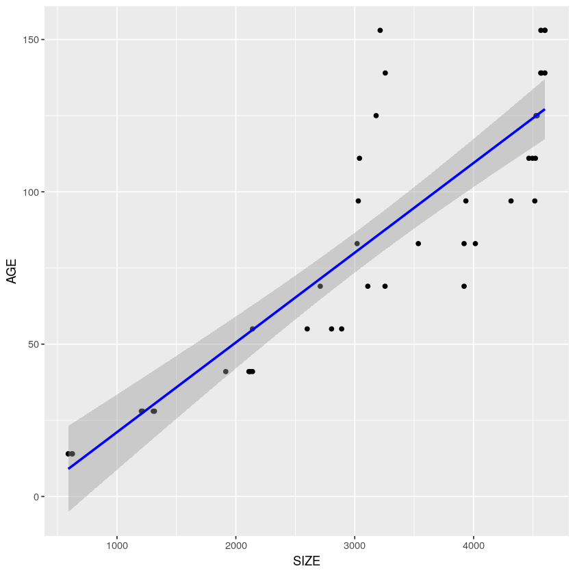

```r
ggplot(data = df, aes(x = SIZE, y = AGE)) +
  geom_point() +
  stat_smooth(method ='lm', col='blue')
```

### Treinando Modelo Multivariado

Passo 9)

Agora vamos treinar o modelo utilizando todas as variáveis disponíveis.

```r
set.seed(149)
model_mult <- train(SIZE~., data = dfTrain ,method = "lm")
```

```r
model_mult
```

```
Linear Regression

32 samples
 2 predictor

No pre-processing
Resampling: Bootstrapped (25 reps)
Summary of sample sizes: 32, 32, 32, 32, 32, 32, ...
Resampling results:

  RMSE      Rsquared   MAE
  537.9325  0.8232577  432.8094

Tuning parameter 'intercept' was held constant at a value of TRUE
```

Passo 10)

Utilizando a função VarImp do mlbench e plotando sua tabela vemos em oredem as features mais importantes do modelos

```
loess r-squared variable importance

            Overall
AGE         0.90877
TEMPERATURE 0.01864
```

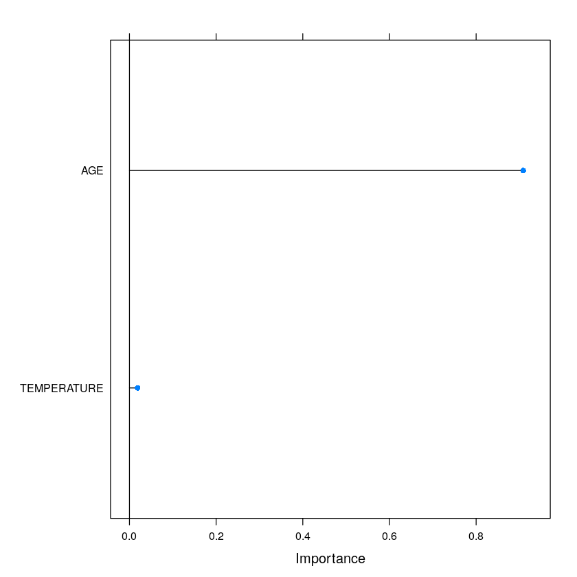

```r
imp <- varImp(model_mult ,useModel=FALSE, scale=FALSE)
imp
plot(imp)
```

Passo 11)

Agora com o modelo treinado podemos fazer o "scoring" nos dados que haviam sindo separados para teste e quaisquer outros que o modelo ainda não tenha visto.

```r
y_Model <- predict(model_mult, dfTest)
dfTest$Model <- y_Model
head(dfTest)
```

|  | AGE | TEMPERATURE | SIZE | Model |
| --- | --- | --- | --- | --- |
| 1 | 14 | 25 | 620 | 1526.800 |
| 9 | 125 | 25 | 4530 | 4471.971 |
| 18 | 97 | 27 | 4315 | 3600.024 |
| 20 | 125 | 27 | 4535 | 4342.950 |
| 25 | 41 | 29 | 2140 | 1985.151 |
| 28 | 83 | 29 | 3920 | 3099.540 |